```r
# Output the current working directory to verify the change
print(getwd())
```

```
## [1] "B:/SLU/4 HDS-5310 Spring (Paul Boal) Analytics and statistical programming"
```

```r
# Ensure the 'readr' library is available for data reading operations
# Uncomment the next line to install the 'readr' library if it's not already installed
# install.packages("readr")
library(readr)
```

```r
# Load the dataset into a dataframe named 'mortality_data'
mortality_data <- read_csv("C:/Users/fazal/Downloads/Deaths_from_Pneumonia_and_Influenza__P_I__and_all_deaths__by_state_and_region__National_Center_For_Hea.csv")
# Display the first few rows of the dataframe to check its structure
head(mortality_data)
```

| geoid | Region | State | age | season | MMWR Year/Week | Deaths from influenza | Deaths from pneumonia | Deaths from pneumonia and influenza | All Deaths | Pecent of deaths due to pneumonia or influenza | pecent complete |
| --- | --- | --- | --- | --- | --- | --- | --- | --- | --- | --- | --- |
| State | NA | Maryland | All | 2017-18 | 201831 | NA | NA | 64 | 949 | 6.743941 | 113.9190 |
| State | NA | Texas | All | 2017-18 | 201819 | NA | NA | 242 | 3664 | 6.604803 | 114.0851 |
| State | NA | Pennsylvania | All | 2017-18 | 201802 | NA | NA | 282 | 3185 | 8.854003 | 132.1936 |
| State | NA | Colorado | All | 2017-18 | 201818 | NA | NA | 41 | 702 | 5.840456 | 114.5518 |
| State | NA | Maryland | All | 2017-18 | 201807 | NA | NA | 87 | 1060 | 8.207547 | 127.2436 |
| State | NA | Virginia | All | 2017-18 | 201802 | NA | NA | 125 | 1555 | 8.038585 | 135.8243 |

```r
##Data Management

# Calculate the number of missing values for each column
missing_values <- sapply(mortality_data, function(x) sum(is.na(x)))

# Displaying the missing values
print(missing_values)
```

```
##                                          geoid
##                                              1
##                                         Region
##                                          27665
##                                          State
##                                           6918
##                                            age
##                                              0
##                                         season
##                                              0
##                                 MMWR Year/Week
##                                              0
##                          Deaths from influenza
##                                          25689
##                          Deaths from pneumonia
##                                          25689
##            Deaths from pneumonia and influenza
##                                             24
##                                     All Deaths
##                                             24
## Pecent of deaths due to pneumonia or influenza
##                                             24
##                                pecent complete
##                                              0
```

```r
# Remove specified columns from the dataframe
mortality_data <- mortality_data[, !colnames(mortality_data) %in% c("Region", "Deaths from influenza", "Deaths from pneumonia")]
```

```r
# Calculating the mode for the 'State' column
mode_state <- names(which.max(table(mortality_data$State, useNA = "no")))
```

```r
# Replace missing values in the 'State' column with the mode
mortality_data$State[is.na(mortality_data$State)] <- mode_state
```

```r
# Omit rows with any remaining missing values
mortality_data <- na.omit(mortality_data)
```

```r
# Check the cleaned dataset
print(head(mortality_data))
```

```
## # A tibble: 6 × 9
##   geoid State  age   season `MMWR Year/Week` Deaths from pneumoni…¹ `All Deaths`
##   <chr> <chr>  <chr> <chr>             <dbl>                  <dbl>        <dbl>
## 1 State Maryl… All   2017-…           201831                     64          949
## 2 State Texas  All   2017-…           201819                    242         3664
## 3 State Penns… All   2017-…           201802                    282         3185
## 4 State Color… All   2017-…           201818                     41          702
## 5 State Maryl… All   2017-…           201807                     87         1060
## 6 State Virgi… All   2017-…           201802                    125         1555
## # ℹ abbreviated name: ¹`Deaths from pneumonia and influenza`
## # ℹ 2 more variables: `Pecent of deaths due to pneumonia or influenza` <dbl>,
## #   `pecent complete` <dbl>
```

##Descriptive analysis

```r
# Function to find unique values for each column
unique_values <- sapply(mortality_data, unique)

# Print unique values
print(unique_values)
```

```
## $geoid
## [1] "State"    "National" "Region"
##
## $State
##  [1] "Maryland"             "Texas"                "Pennsylvania"
##  [4] "Colorado"             "Virginia"             "District of Columbia"
##  [7] "Massachusetts"        "Alabama"              "California"
## [10] "Wyoming"              "South Carolina"       "Montana"
## [13] "Rhode Island"         "Ohio"                 "New Hampshire"
## [16] "New Jersey"           "North Dakota"         "Nevada"
## [19] "Iowa"                 "Oklahoma"             "Missouri"
## [22] "Arkansas"             "Minnesota"            "Arizona"
## [25] "Kansas"               "Kentucky"             "Florida"
## [28] "South Dakota"         "Maine"                "Illinois"
## [31] "Delaware"             "Utah"                 "Tennessee"
```

[output cut: 6505 more lines]

```r
# Define a function to calculate the mode
calculate_mode <- function(x) {
  ux <- unique(x)
  ux[which.max(tabulate(match(x, ux)))]
}
```

```r
# Apply the mode calculation function to each column in the dataframe
mode_values <- sapply(mortality_data, calculate_mode)

# Print the modes for each column
print(mode_values)
```

```
##                                          geoid
##                                        "State"
##                                          State
##                                      "Alabama"
##                                            age
##                                          "All"
##                                         season
##                                      "2014-15"
##                                 MMWR Year/Week
##                                       "201731"
##            Deaths from pneumonia and influenza
##                                           "12"
##                                     All Deaths
##                                           "90"
## Pecent of deaths due to pneumonia or influenza
##                                         "6.25"
##                                pecent complete
##                                 "100.77685508"
```

```r
# Calculate standard deviation for each numeric column in the dataframe
std_deviation <- sapply(mortality_data, function(x) if(is.numeric(x)) sd(x, na.rm = TRUE))

# Print the standard deviations
print(std_deviation)
```

```
## $geoid
## NULL
##
## $State
## NULL
##
## $age
## NULL
##
## $season
## NULL
##
## $`MMWR Year/Week`
## [1] 273.7417
##
## $`Deaths from pneumonia and influenza`
## [1] 593.6283
##
## $`All Deaths`
## [1] 7757.819
##
## $`Pecent of deaths due to pneumonia or influenza`
## [1] 2.103551
##
## $`pecent complete`
## [1] 10.45797
```

```r
# Convert 'geoid' categories to specified numbers
mortality_data$geoid <- factor(mortality_data$geoid, levels = c("State", "National", "Region"), labels = c(1, 2, 3))

# Convert 'age' categories to specified numbers
mortality_data$age <- factor(mortality_data$age, levels = c("All", "65 years and older", "18-64 years", "0-17 years"), labels = c(1, 2, 3, 4))

# Convert 'season' categories to specified numbers
# First, ensure all mentioned seasons are listed and arranged in the specified order
mortality_data$season <- factor(mortality_data$season, levels = c("2017-18", "2018-19", "2015-16", "2014-15", "2016-17", "2009-10", "2012-13", "2013-14", "2010-11", "2011-12"),
                      labels = c(1, 2, 3, 4, 5, 6, 7, 8, 9, 10))
```

```r
# Print the modified data to check the changes
print(head(mortality_data))
```

```
## # A tibble: 6 × 9
##   geoid State  age   season `MMWR Year/Week` Deaths from pneumoni…¹ `All Deaths`
##   <fct> <chr>  <fct> <fct>             <dbl>                  <dbl>        <dbl>
## 1 1     Maryl… 1     1                201831                     64          949
## 2 1     Texas  1     1                201819                    242         3664
## 3 1     Penns… 1     1                201802                    282         3185
## 4 1     Color… 1     1                201818                     41          702
## 5 1     Maryl… 1     1                201807                     87         1060
## 6 1     Virgi… 1     1                201802                    125         1555
## # ℹ abbreviated name: ¹`Deaths from pneumonia and influenza`
## # ℹ 2 more variables: `Pecent of deaths due to pneumonia or influenza` <dbl>,
## #   `pecent complete` <dbl>
```

```r
library(dplyr)
library(modeest)
summary(mortality_data)
```

```
##  geoid        State           age           season      MMWR Year/Week
##  1:25665   Length:32582       1:31100   4      : 3498   Min.   :200940
##  2: 1976   Class :character   2:  494   5      : 3433   1st Qu.:201207
##  3: 4941   Mode  :character   3:  494   8      : 3433   Median :201426
##                               4:  494   1      : 3432   Mean   :201425
##                                         3      : 3432   3rd Qu.:201645
##                                         6      : 3432   Max.   :201912
##                                         (Other):11922
##  Deaths from pneumonia and influenza   All Deaths
##  Min.   :   0.0                      Min.   :   23.0
##  1st Qu.:  27.0                      1st Qu.:  398.2
##  Median :  66.0                      Median :  946.0
##  Mean   : 222.9                      Mean   : 3074.2
##  3rd Qu.: 147.0                      3rd Qu.: 2061.0
##  Max.   :7104.0                      Max.   :67407.0
##
##  Pecent of deaths due to pneumonia or influenza pecent complete
##  Min.   : 0.000                                 Min.   : 25.62
##  1st Qu.: 5.861                                 1st Qu.: 99.53
##  Median : 7.006                                 Median :105.65
##  Mean   : 7.196                                 Mean   :106.85
##  3rd Qu.: 8.365                                 3rd Qu.:113.01
##  Max.   :21.505                                 Max.   :169.25
##
```

This R script conducts a descriptive analysis of mortality_data. It identifies unique values for each column and calculates the mode to determine the most frequently occurring values. For numeric columns, it computes the standard deviation to measure data variability. The script also re-categorizes specific columns like geoid, age, and season into numeric codes for easier analysis. Factors are applied to ensure that each category corresponds to a unique numeric value based on predefined levels. It concludes by displaying the transformed data and using additional libraries, dplyr and modeest, to summarize the refined dataset comprehensively.

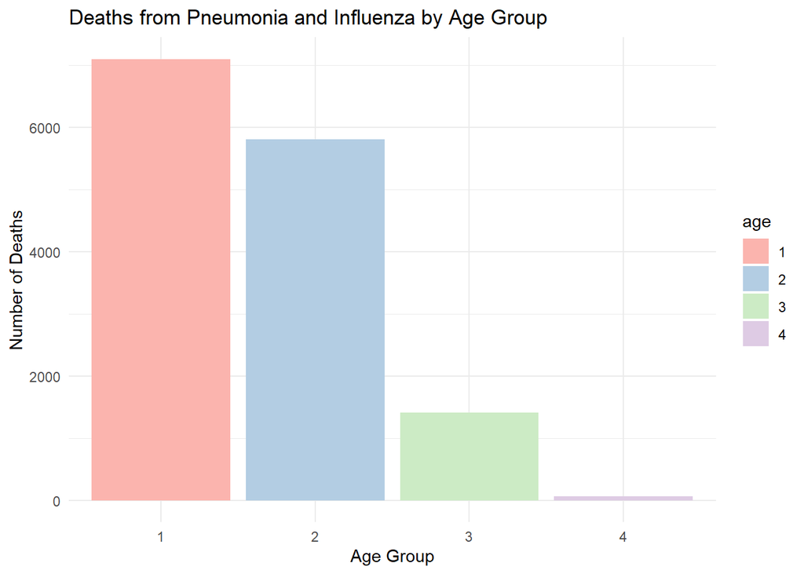

```r
##Data visualization

library(ggplot2)  # For creating graphics
library(readr)    # For reading data

# Create a bar plot of Deaths from pneumonia and influenza by age group
ggplot(mortality_data, aes(x = age, y = `Deaths from pneumonia and influenza`, fill = age)) +
  geom_bar(stat = "identity", position = "dodge") +
  theme_minimal() +  # Using a minimal theme for a cleaner look
  labs(title = "Deaths from Pneumonia and Influenza by Age Group", x = "Age Group", y = "Number of Deaths") +
  scale_fill_brewer(palette = "Pastel1")
```

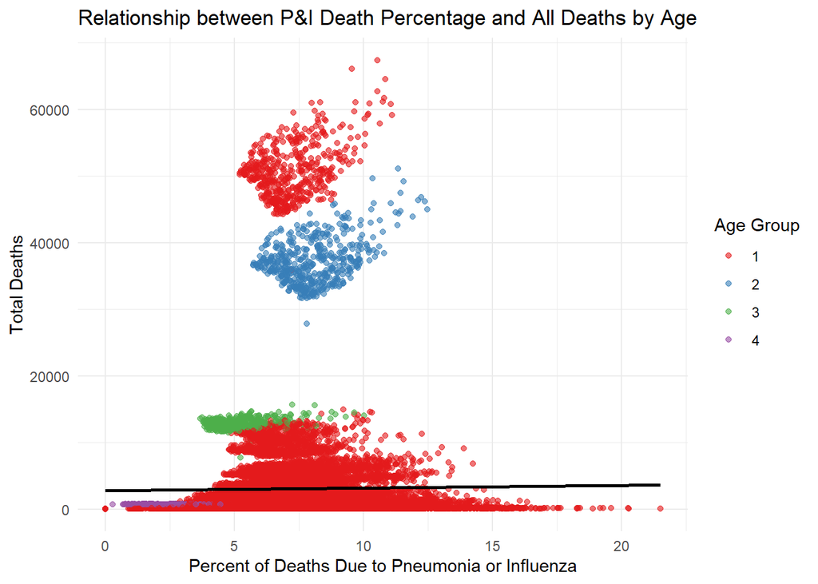

```r
# Create a scatter plot to investigate the relationship between the two variables by age
ggplot(mortality_data, aes(x = `Pecent of deaths due to pneumonia or influenza`, y = `All Deaths`, color = age)) +
  geom_point(alpha = 0.6) +  # Setting transparency to see overlapping points
  geom_smooth(method = "lm", se = FALSE, color = "black") +  # Adding a linear regression line without a confidence interval
  theme_minimal() +  # Using a minimal theme for a clean look
  labs(title = "Relationship between P&I Death Percentage and All Deaths by Age",
       x = "Percent of Deaths Due to Pneumonia or Influenza",
       y = "Total Deaths",
       color = "Age Group") +
  scale_color_brewer(type = "qual", palette = "Set1")
```

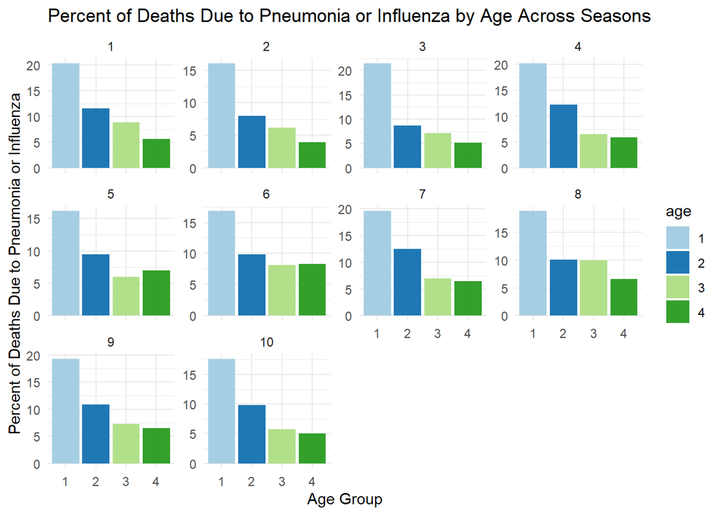

```r
# Create a faceted bar chart to display the percent of deaths due to pneumonia or influenza by age and season
ggplot(mortality_data, aes(x = age, y = `Pecent of deaths due to pneumonia or influenza`, fill = age)) +
  geom_bar(stat = "identity", position = "dodge") +
  facet_wrap(~ season, scales = "free_y") +  # Faceting by season with independent y scales
  theme_minimal() +  # Applying a minimal theme for clarity
  labs(title = "Percent of Deaths Due to Pneumonia or Influenza by Age Across Seasons",
       x = "Age Group",
       y = "Percent of Deaths Due to Pneumonia or Influenza") +
  scale_fill_brewer(type = "qual", palette = "Paired")
```

This R script creates visual representations of mortality data using the ggplot2 and readr libraries. It features a bar plot displaying deaths from pneumonia and influenza by age group, emphasizing differences between age categories with a pastel color palette. A scatter plot explores the relationship between the percentage of deaths due to pneumonia or influenza and total deaths across age groups, including a linear regression line to highlight trends without confidence intervals. Lastly, a faceted bar chart visualizes the percentage of pneumonia or influenza deaths across different seasons and age groups, using independent y-axes for clarity and a paired color palette to differentiate between age groups effectively. These visualizations help elucidate patterns and relationships within the data.

```r
##Statistcal Test and Assumptions

# Correlation test for P&I deaths and all deaths
cor_test <- cor.test(mortality_data$`Deaths from pneumonia and influenza`, mortality_data$`All Deaths`, method = "pearson")
print(cor_test)
```

```
##
##  Pearson's product-moment correlation
##
## data:  mortality_data$`Deaths from pneumonia and influenza` and mortality_data$`All Deaths`
## t = 888.42, df = 32580, p-value < 2.2e-16
## alternative hypothesis: true correlation is not equal to 0
## 95 percent confidence interval:
##  0.9795437 0.9804047
## sample estimates:
##       cor
## 0.9799788
```

```r
# ANOVA for P&I deaths by State
anova_results <- aov(`Deaths from pneumonia and influenza` ~ State, data = mortality_data)
summary(anova_results)
```

```
##                Df    Sum Sq  Mean Sq F value Pr(>F)
## State          51 2.692e+09 52784351   195.4 <2e-16 ***
## Residuals   32530 8.789e+09   270193
## ---
## Signif. codes:  0 '***' 0.001 '**' 0.01 '*' 0.05 '.' 0.1 ' ' 1
```

```r
# Kruskal-Wallis test for all deaths by State, a non-parametric method
kruskal_test <- kruskal.test(`All Deaths` ~ State, data = mortality_data)
print(kruskal_test)
```

```
##
##  Kruskal-Wallis rank sum test
##
## data:  All Deaths by State
## Kruskal-Wallis chi-squared = 29744, df = 51, p-value < 2.2e-16
```

This R script performs statistical tests to analyze relationships and differences within the mortality_data dataset. First, a Pearson correlation test examines the linear relationship between the number of deaths from pneumonia and influenza and total deaths, indicating the strength and direction of the association. Next, an ANOVA (Analysis of Variance) test assesses whether there are statistically significant differences in deaths from pneumonia and influenza across different states, ideal for comparing means among groups. Lastly, the Kruskal-Wallis test, a non-parametric alternative to ANOVA, checks for differences in the distribution of total deaths by state, suitable for non-normally distributed data or ordinal categories. This approach provides comprehensive insights into the data’s characteristics and relationships.

```r
##Post Hocs and Standarized Residuals

# Conducting Tukey's HSD test if ANOVA is significant
if (summary(anova_results)[[1]][["Pr(>F)"]][1] < 0.05) {
  tukey_test <- TukeyHSD(anova_results)
  print(tukey_test)
} else {
  print("No significant differences found by ANOVA; no need for post-hoc analysis.")
}
```

```
##   Tukey multiple comparisons of means
##     95% family-wise confidence level
##
## Fit: aov(formula = `Deaths from pneumonia and influenza` ~ State, data = mortality_data)
##
## $State
##                                              diff          lwr         upr
## Alaska-Alabama                      -734.62667815 -831.4951963 -637.758160
## Arizona-Alabama                     -675.09226519 -771.9607833 -578.223747
## Arkansas-Alabama                    -692.74206276 -789.6105809 -595.873545
## California-Alabama                  -323.26432997 -420.1328481 -226.395812
## Colorado-Alabama                    -696.49307491 -793.3615930 -599.624557
## Connecticut-Alabama                 -695.81804285 -793.7152245 -597.920861
## Delaware-Alabama                    -728.75825709 -825.6267752 -631.889739
## District of Columbia-Alabama        -733.53558503 -830.4041032 -636.667067
## Florida-Alabama                     -534.84732592 -631.7158441 -437.978808
## Georgia-Alabama                     -650.55582794 -747.4243461 -553.687310
## Hawaii-Alabama                      -718.20764981 -815.0761679 -621.339132
## Idaho-Alabama                       -723.80684009 -820.6753582 -626.938322
## Illinois-Alabama                    -591.95866195 -688.8271801 -495.090144
## Indiana-Alabama                     -651.37769029 -748.2462084 -554.509172
## Iowa-Alabama                        -695.94246762 -792.8109858 -599.073949
## Kansas-Alabama                      -702.29874292 -799.1672611 -605.430225
## Kentucky-Alabama                    -665.08619232 -761.9547105 -568.217674
## Louisiana-Alabama                   -693.58011944 -790.4486376 -596.711601
## Maine-Alabama                       -720.05785224 -816.9263704 -623.189334
## Maryland-Alabama                    -673.45461337 -770.3231315 -576.586095
## Massachusetts-Alabama               -648.47890487 -745.3474230 -551.610387
## Michigan-Alabama                    -619.00319636 -715.8717145 -522.134678
## Minnesota-Alabama                   -682.60643523 -779.4749534 -585.737917
## Mississippi-Alabama                 -697.65299394 -794.5215121 -600.784476
## Missouri-Alabama                    -660.56999798 -757.4385161 -563.701480
## Montana-Alabama                     -727.60036236 -824.4688805 -630.731844
## Nebraska-Alabama                    -714.84125304 -811.7097712 -617.972735
## Nevada-Alabama                      -709.11453240 -805.9830505 -612.246014
## New Hampshire-Alabama               -723.42222470 -820.2907428 -626.553707
## New Jersey-Alabama                  -653.16513968 -750.0336578 -556.296622
## New Mexico-Alabama                  -714.39995750 -811.2684756 -617.531439
## New York-Alabama                    -587.63679960 -684.5053177 -490.768281
## New York City-Alabama               -644.16391685 -741.4024020 -546.925432
```

[output cut: 2605 more lines]

```
## Virginia-Vermont                    0.9970369
## Washington-Vermont                  0.9993865
## West Virginia-Vermont               1.0000000
## Wisconsin-Vermont                   0.9999952
## Wyoming-Vermont                     1.0000000
## Washington-Virginia                 1.0000000
## West Virginia-Virginia              1.0000000
## Wisconsin-Virginia                  1.0000000
## Wyoming-Virginia                    0.9946048
## West Virginia-Washington            1.0000000
## Wisconsin-Washington                1.0000000
## Wyoming-Washington                  0.9987282
## Wisconsin-West Virginia             1.0000000
## Wyoming-West Virginia               1.0000000
## Wyoming-Wisconsin                   0.9999855
```

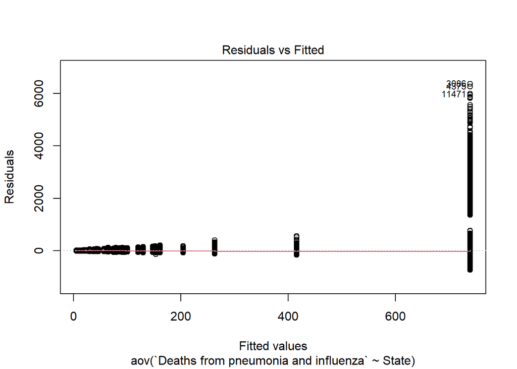

```r
# Diagnostic plot for residuals
plot(anova_results, which = 1)
```

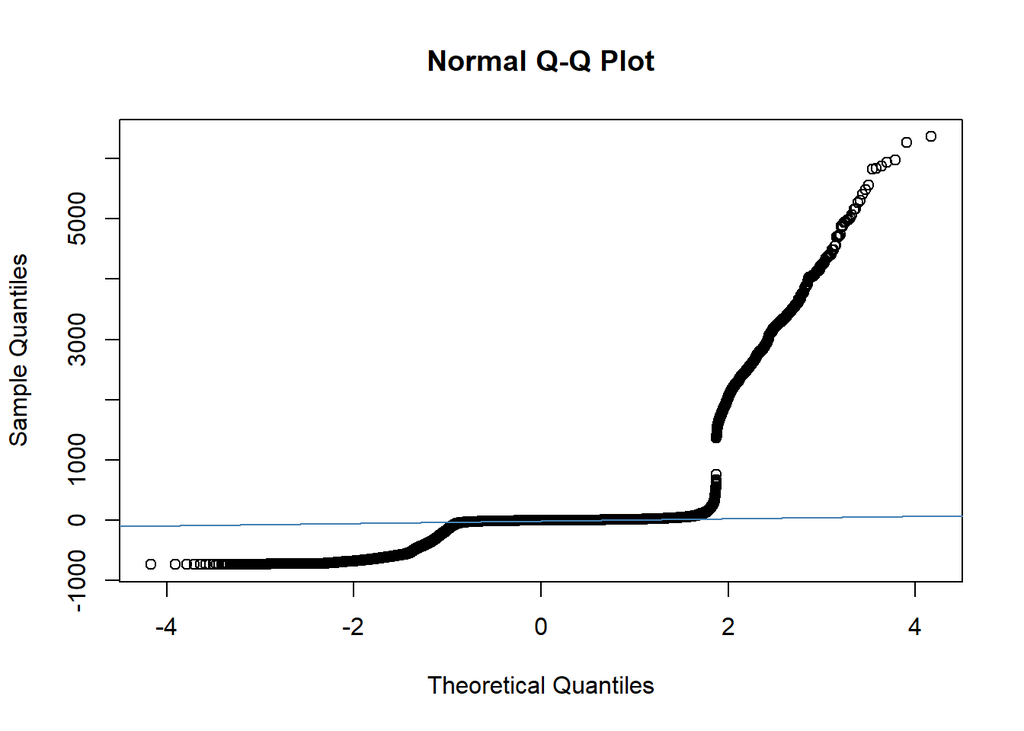

```r
# Check for normality of residuals
qqnorm(residuals(anova_results))
qqline(residuals(anova_results), col = "steelblue")
```

```r
if (length(residuals(anova_results)) > 5000) {
  sampled_residuals <- sample(residuals(anova_results), 5000)
  shapiro_test <- shapiro.test(sampled_residuals)
} else {
  shapiro_test <- shapiro.test(residuals(anova_results))
}
print(shapiro_test)
```

```
##
##  Shapiro-Wilk normality test
##
## data:  sampled_residuals
## W = 0.42003, p-value < 2.2e-16
```

This R script segment handles post-hoc analysis and diagnostic checks following an ANOVA test. If the ANOVA indicates significant differences in pneumonia and influenza deaths across states (p-value < 0.05), it proceeds with Tukey’s Honest Significant Difference (HSD) test to identify specific group differences. It also visualizes the ANOVA residuals to assess assumptions about data distribution and homoscedasticity. Normality of residuals is checked using a Q-Q plot, enhanced with a reference line. If the dataset is large (over 5000 residuals), a sample is tested for normality using the Shapiro-Wilk test to manage performance; otherwise, all residuals are tested directly, ensuring that the analysis is thorough and efficient in diagnosing model fit and validity.

```r
##Effect size measurement

library(effsize)
# Calculate the percentage of deaths due to P&I for each observation
mortality_data$Pecent_of_PandI_Deaths <- with(mortality_data, (`Deaths from pneumonia and influenza` / `All Deaths`) * 100)

# Calculate the overall average percentage of P&I deaths
average_PandI <- mean(mortality_data$Pecent_of_PandI_Deaths, na.rm = TRUE)
```

```r
# Create two groups based on the average percentage
mortality_data$Risk_Group <- ifelse(mortality_data$Pecent_of_PandI_Deaths > average_PandI, "High-Risk", "Low-Risk")

# View the first few rows of the updated dataset to verify the groups
head(mortality_data)
```

| geoid | State | age | season | MMWR Year/Week | Deaths from pneumonia and influenza | All Deaths | Pecent of deaths due to pneumonia or influenza | pecent complete | Pecent_of_PandI_Deaths | Risk_Group |
| --- | --- | --- | --- | --- | --- | --- | --- | --- | --- | --- |
| 1 | Maryland | 1 | 1 | 201831 | 64 | 949 | 6.743941 | 113.9190 | 6.743941 | Low-Risk |
| 1 | Texas | 1 | 1 | 201819 | 242 | 3664 | 6.604803 | 114.0851 | 6.604803 | Low-Risk |
| 1 | Pennsylvania | 1 | 1 | 201802 | 282 | 3185 | 8.854003 | 132.1936 | 8.854003 | High-Risk |
| 1 | Colorado | 1 | 1 | 201818 | 41 | 702 | 5.840456 | 114.5518 | 5.840456 | Low-Risk |
| 1 | Maryland | 1 | 1 | 201807 | 87 | 1060 | 8.207547 | 127.2436 | 8.207547 | High-Risk |
| 1 | Virginia | 1 | 1 | 201802 | 125 | 1555 | 8.038585 | 135.8243 | 8.038585 | High-Risk |

```r
# Optionally, summarize the data to see the distribution across groups
summary_stats <- mortality_data %>%
  group_by(Risk_Group) %>%
  summarise(
    Average_PandI_Deaths = mean(Pecent_of_PandI_Deaths, na.rm = TRUE),
    Count = n()
  )
print(summary_stats)
```

```
## # A tibble: 2 × 3
##   Risk_Group Average_PandI_Deaths Count
##   <chr>                     <dbl> <int>
## 1 High-Risk                  8.94 14975
## 2 Low-Risk                   5.72 17607
```

```r
# Filter data for the two groups
high_risk_data <- mortality_data$Pecent_of_PandI_Deaths[mortality_data$Risk_Group == "High-Risk"]
low_risk_data <- mortality_data$Pecent_of_PandI_Deaths[mortality_data$Risk_Group == "Low-Risk"]

# Perform t-test
t_test_result <- t.test(high_risk_data, low_risk_data)

# Calculate Cohen's d for effect size
cohen_d_result <- cohen.d(high_risk_data, low_risk_data)
print(t_test_result)
```

```
##
##  Welch Two Sample t-test
##
## data:  high_risk_data and low_risk_data
## t = 207.81, df = 27113, p-value < 2.2e-16
## alternative hypothesis: true difference in means is not equal to 0
## 95 percent confidence interval:
##  3.188583 3.249306
## sample estimates:
## mean of x mean of y
##  8.935088  5.716144
```

```r
print(cohen_d_result)
```

```
##
## Cohen's d
##
## d estimate: 2.365715 (large)
## 95 percent confidence interval:
##    lower    upper
## 2.337348 2.394082
```

This R script enhances mortality_data by calculating the percentage of deaths due to pneumonia and influenza (P&I) for each entry and categorizing observations into risk groups based on the overall average percentage of P&I deaths. Observations above the mean are labeled “High-Risk” and those below are “Low-Risk.” It then summarizes the average percentage of P&I deaths and counts within each risk group. For a comparative analysis between these groups, a t-test is performed to assess statistical differences in the percentage of P&I deaths. Additionally, Cohen’s d is computed to quantify the effect size, providing a measure of the strength of the relationship between the risk groups, thereby offering a comprehensive view of the data’s distribution and differences across risk categories.

```r
##Linear regression

set.seed(123)  # for reproducibility

# Loading necessary libraries
library(caret)
# Splitting data into training and testing sets
trainIndex <- createDataPartition(mortality_data$`Pecent of deaths due to pneumonia or influenza`, p = .8,
                                  list = FALSE,
                                  times = 1)
trainData <- mortality_data[trainIndex, ]
testData <- mortality_data[-trainIndex, ]

# Fit linear regression model
model <- lm(`Pecent of deaths due to pneumonia or influenza` ~ ., data = trainData)

# Predictions
predictions <- predict(model, newdata = testData)
```

```r
# Calculate RMSE for the prediction
rmse <- sqrt(mean((predictions - testData$`Pecent of deaths due to pneumonia or influenza`)^2))
```

```r
# Print RMSE results
print(paste("RMSE for Pecent of deaths due to pneumonia or influenza:", rmse))
```

```
## [1] "RMSE for Pecent of deaths due to pneumonia or influenza: 8.93239306411786e-11"
```

This R script sets up a linear regression model to predict the percentage of deaths due to pneumonia or influenza using the mortality_data dataset. It begins by setting a random seed for reproducibility and loading the caret library, which provides tools for data splitting, model training, and prediction. The dataset is then divided into training (80%) and testing (20%) sets. A linear regression model is fitted on the training data, using all available predictors. Predictions are made on the test dataset, and the Root Mean Square Error (RMSE) is calculated to evaluate the model’s accuracy. The RMSE quantifies the prediction error, providing a straightforward metric to assess the model’s performance. The result is displayed, showing the effectiveness of the model in predicting the outcome based on the test data.

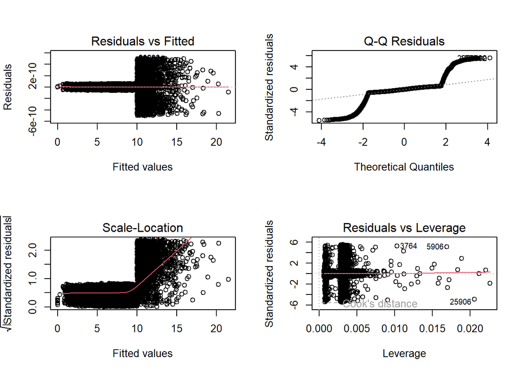

```r
#Additional Analyses
# Diagnostic plots for assessing model assumptions
par(mfrow = c(2, 2))
plot(model)
```

```r
# Checking for independence with Durbin-Watson Test
library(lmtest)
dwtest(model)
```

```
##
##  Durbin-Watson test
##
## data:  model
## DW = 1.9832, p-value = 0.0866
## alternative hypothesis: true autocorrelation is greater than 0
```

```r
# Checking for homoscedasticity with Breusch-Pagan test
bptest(model)
```

```
##
##  studentized Breusch-Pagan test
##
## data:  model
## BP = 7376.9, df = 71, p-value < 2.2e-16
```

This R script performs additional analyses to assess the assumptions of the linear regression model fitted to the mortality_data. It starts with diagnostic plots arranged in a 2x2 grid to visually evaluate model assumptions including linearity, normality of residuals, homoscedasticity, and leverage points. Following the plots, the script checks for independence of residuals using the Durbin-Watson test, which identifies autocorrelation issues. It then uses the lmtest library for this purpose. To assess homoscedasticity, the Breusch-Pagan test is conducted, determining if the variance of residuals is constant across levels of the independent variables. These tests help ensure the validity of the regression model’s results by verifying key statistical assumptions.